# Validation Analysis

Mia Charifson

2024-06-03

Last updated on: 2024-07-03.

# Background

This document performs the analysis for the chart review validation study of identifying incident UF and Endo from EHR.

The final analysis will produce positive predictive value, sensitivity, specificity and negative predictive value for three methods of defining cases:

1. ICD code only
2. ICD code plus diagnostic procedure (within 6 months)
3. Our algorithm

There are also special investigations into hesitant cases, potential false negatives and patients with both conditions.

According to the SDAVV method:

```r
## SDAVV method for sample size
expected <- 0.8
lower <- 0.7

n <- round(((1.96^2)*expected*(1-expected))/((expected-lower)^2), 2)
print(paste('We need at least n=', n, 'patients randomly selected from each group to review, for a expected PPV/NPV of', expected, 'and a critical lower bound of', lower))
```

```
## [1] "We need at least n= 61.47 patients randomly selected from each group to review, for a expected PPV/NPV of 0.8 and a critical lower bound of 0.7"
```

# Cleaning the data

```r
redcap_df <- read.csv('Data/Derived/Chart Review/export_data_20240619.csv')
second_review <- read.csv('Data/Derived/Chart Review/export_secondary_review_20240620.csv')
chart_info <- read.csv('Data/Derived/Chart Review/all_chart_cases_w_info.csv')
uf_cohort <- read.csv('Data/Derived/uf_all_hints.csv')
endo_cohort <- read.csv('Data/Derived/endo_all_hints.csv')
false_negatives <- read.csv('Data/Derived/putative_false_negatives.csv')
pat_cohort <- read.csv('Data/Derived/pat_cohort_w_censoring.csv')
adeno <- read.csv('Data/Derived/clean_covariates.csv') %>% select(pat_id, contains('adeno'))
```

```r
chart_info <- chart_info %>% mutate(condition = ifelse(is.na(condition), 'None', condition))
redcap_df <- redcap_df %>% filter(redcap_event_name != 'secondary_review_arm_7')
false_neg_ids <- false_negatives$pat_id[which(!false_negatives$ever_imaging & !false_negatives$ever_surgery)]
```

Cleaning the data from EHR:

```r
uf_final <- uf_cohort %>%
  # redo endo definition without referral & prevalent dx
  mutate(confident_incident = case_when(confident_prevalent~FALSE,
                                        ever_confirmed_6months | any_location |
                                          #multiple_referral | prevalent_dx_after_proc |
                                          ever_pregnancy_related | dx_after_partial_LTFU~TRUE,
                                        TRUE~FALSE)) %>%
  select(pat_id, confident_incident, confident_prevalent, first_dx_date, first_confirm_date,
         first_confirm_type, first_location_date, imaging_confirmed, surgery_confirmed) %>%
  mutate(icd_confirmed = TRUE,
         algorithm = case_when(confident_incident~'Incident', !confident_incident~'Prevalent')) %>%
  rename_at(vars(confident_incident:algorithm), ~paste0("uf_", .))

endo_final <- endo_cohort %>%
  # add Adeno information to try to identify false positives
  left_join(adeno, by='pat_id') %>%
  # redo endo definition without referral & prevalent dx
  mutate(false_positive = first_dx_type == 'Hospital Account Diagnosis' & dx_count <= 2 & adeno_final=='Yes',
         confident_incident = case_when(false_positive | confident_prevalent~FALSE,
                                        ever_confirmed_6months | any_location |
                                          #multiple_referral | prevalent_dx_after_proc |
                                          dx_via_laparoscopy | dx_after_partial_LTFU~TRUE,
                                        TRUE~FALSE)) %>%
  select(pat_id, confident_incident, confident_prevalent, first_dx_date, first_confirm_date,
         first_confirm_type, first_location_date, imaging_confirmed, surgery_confirmed, false_positive) %>%
  mutate(icd_confirmed = TRUE,
         algorithm = case_when(false_positive~'No Dx',
                               confident_incident~'Incident',
                               !confident_incident~'Prevalent')) %>%
  rename_at(vars(confident_incident:algorithm), ~paste0("endo_", .))

pred_df_all <- pat_cohort %>%
  select(pat_mrn_id, pat_id, index_enc_date) %>% rename(mrn=pat_mrn_id) %>%
  left_join(uf_final, by='pat_id') %>%
  left_join(endo_final, by='pat_id') %>%
  # fill in NA for rest of cohort
  mutate_at(vars(uf_confident_incident, uf_imaging_confirmed:uf_icd_confirmed), ~ifelse(is.na(.), FALSE, .)) %>%
  mutate_at(vars(endo_confident_incident, endo_imaging_confirmed:endo_icd_confirmed), ~ifelse(is.na(.), FALSE,
                                                                                              .)) %>%
  # make those missing outcome to NA and make final outcome
  mutate(uf_algorithm = case_when(is.na(uf_algorithm)~'No Dx', TRUE~uf_algorithm),
         endo_algorithm = case_when(is.na(endo_algorithm)~'No Dx', TRUE~endo_algorithm),
         uf_first_dx_date = as.Date(uf_first_dx_date),
         endo_first_dx_date = as.Date(endo_first_dx_date),
         final_outcome_status = case_when(uf_algorithm=='Incident' &
                                            endo_algorithm=='Incident' ~'Both Incident',
                                          uf_algorithm=='Incident' &
                                            endo_algorithm!='Incident'~'Incident UF only',
                                          uf_algorithm!='Incident' &
                                            endo_algorithm=='Incident'~'Incident Endo only',
                                          uf_icd_confirmed & uf_algorithm!='Incident'~ 'UF unconfirmed',
                                          endo_icd_confirmed & endo_algorithm!='Incident'~ 'Endo unconfirmed',
                                          pat_id %in% false_neg_ids~'Potential false negative',
                                          TRUE~'Neither incident'))

pred_df <- pred_df_all %>% filter(mrn %in% chart_info$mrn)
```

Cleaning the data from chart review:

```r
true_df_clean <-  redcap_df %>%
  filter(secondary_review_final != 1 | is.na(secondary_review_final)) %>%
  bind_rows(second_review %>% mutate(secondary_review_final==1)) %>%
  # derive outcome status based on different definitions
  mutate(uf_clinical_chart = case_when(medical_hx_uf==1|problem_list_uf==1|prior_dx_uf==1~TRUE,TRUE~FALSE),
         uf_imaging_chart = case_when(imaging_confirmed_uf==1~TRUE,TRUE~FALSE),
         uf_surgery_chart = case_when(surgery_confirmed_uf==1~TRUE,TRUE~FALSE),
         uf_any_chart = case_when(uf_clinical_chart==1|uf_imaging_chart==1|uf_surgery_chart==1~TRUE,TRUE~FALSE),
         endo_clinical_chart = case_when(medical_hx_endo==1|problem_list_endo==1|prior_dx_endo==1~TRUE,TRUE~FALSE),
         endo_imaging_chart = case_when(imaging_confirmed_endo==1~TRUE,TRUE~FALSE),
         endo_surgery_chart = case_when(surgery_confirmed_endo==1~TRUE,TRUE~FALSE),
         endo_any_chart = case_when(endo_clinical_chart==1|endo_imaging_chart==1|endo_surgery_chart==1~TRUE,
                                    TRUE~FALSE)) %>%
  # derive earliest dx date from date variables
  mutate(across((contains('date') | contains('entry')) & !contains('prior_dx_date'), ~as.Date(.,  '%m/%d/%y'))) %>%
  mutate(prior_dx_date_uf_clean = case_when(
    grepl('[0-9]{1,2}/[0-9]{1,2}/[0-9]{1,2}', prior_dx_date_uf, perl=TRUE)~as.Date(prior_dx_date_uf, '%m/%d/%y'),
    grepl('[0-9]{1,2}-[0-9]{1,2}-[0-9]{1,4}', prior_dx_date_uf, perl=TRUE)~as.Date(prior_dx_date_uf, '%m-%d-%Y'),
    grepl('[0-9]{1,2}/[0-9]{1,2}/[0-9]{4}', prior_dx_date_uf, perl=TRUE)~as.Date(prior_dx_date_uf, '%m/%d/%Y'),
    grepl('[a-zA-Z]{3}-[0-9]{1,2}', prior_dx_date_uf, perl=TRUE)~
      as.Date(paste0('01-', prior_dx_date_uf), '%d-%b-%y'),
    grepl('[0-9]{1,4}', prior_dx_date_uf, perl=TRUE)~as.Date(paste0('01-01-', prior_dx_date_uf), '%m-%d-%Y'),
    TRUE~NA)) %>%
  mutate(prior_dx_date_endo_clean = case_when(
    grepl('[0-9]{1,2}/[0-9]{1,2}/[0-9]{1,2}', prior_dx_date_endo, perl=TRUE)~as.Date(prior_dx_date_endo, '%m/%d/%y'),
    grepl('[0-9]{1,2}-[0-9]{1,2}-[0-9]{1,4}', prior_dx_date_endo, perl=TRUE)~as.Date(prior_dx_date_endo, '%m-%d-%Y'),
    grepl('[0-9]{1,2}/[0-9]{1,2}/[0-9]{4}', prior_dx_date_endo, perl=TRUE)~as.Date(prior_dx_date_endo, '%m/%d/%Y'),
    grepl('[a-zA-Z]{3}-[0-9]{1,2}', prior_dx_date_endo, perl=TRUE)~
      as.Date(paste0('01-', prior_dx_date_endo), '%d-%b-%y'),
    grepl('[0-9]{1,4}', prior_dx_date_endo, perl=TRUE)~as.Date(paste0('01-01-', prior_dx_date_endo), '%m-%d-%Y'),
    TRUE~NA)) %>%
  mutate(prior_dx_date_endo_clean = as.Date(prior_dx_date_endo_clean),
         prior_dx_date_uf_clean = as.Date(prior_dx_date_uf_clean)) %>%
  # determine earliest dx date
  mutate(uf_earliest_dx_date = pmin(medical_hx_date_uf, problem_list_date_uf, imaging_confirmed_date_uf,
                                    surgery_confirmed_date_uf, prior_dx_entry_uf,
                                    prior_dx_date_uf_clean, na.rm=TRUE),
         endo_earliest_dx_date = pmin(medical_hx_date_endo, problem_list_date_endo, imaging_confirmed_date_endo,
                                      surgery_confirmed_date_endo, prior_dx_entry_endo,
                                      prior_dx_date_endo_clean, na.rm=TRUE)) %>%
  # if earliest date is only from note entry then flag
  mutate(uf_gold_date_flag = case_when(is.na(coalesce(medical_hx_date_uf,problem_list_date_uf,
                                                      imaging_confirmed_date_uf,surgery_confirmed_date_uf,
                                                      prior_dx_date_uf_clean)) &
                                         prior_dx_entry_uf == uf_earliest_dx_date~TRUE,
                                       TRUE~FALSE),
         endo_gold_date_flag = case_when(is.na(coalesce(medical_hx_date_endo,problem_list_date_endo,
                                                      imaging_confirmed_date_endo,surgery_confirmed_date_endo,
                                                      prior_dx_date_endo_clean)) &
                                           prior_dx_entry_endo == endo_earliest_dx_date~TRUE,
                                         TRUE~FALSE)) %>%
  # make final determination for prevalent vs. incident
  mutate(uf_gold_dx = case_when(uf_any_chart & uf_earliest_dx_date <= '2016-08-01'~'Prevalent',
                                uf_any_chart & uf_earliest_dx_date > '2016-08-01'~'Incident',
                                uf_any_chart & is.na(uf_earliest_dx_date)~'Incident',
                                TRUE~'No Dx'),
         endo_gold_dx = case_when(endo_any_chart & endo_earliest_dx_date <= '2016-08-01'~'Prevalent',
                                  endo_any_chart & endo_earliest_dx_date > '2016-08-01'~'Incident',
                                  endo_any_chart & is.na(endo_earliest_dx_date)~'Incident',
                                  TRUE~'No Dx')) %>%
  select(mrn, uf_clinical_chart:endo_gold_dx, contains('date'), contains('entry'), notes_final)
```

Manually check the second review cases (n=31):

```r
true_df_clean %>%
  filter(mrn %in% second_review$mrn) %>%
  left_join(second_review %>% select(mrn, notes_final), by='mrn') %>%
  select(mrn, uf_gold_dx, endo_gold_dx, notes_final) %>%
  View()
```

```r
remove_incident_uf <- true_df_clean$mrn[which(true_df_clean$mrn %in% second_review$mrn)][c(5,7)]
true_df_clean$uf_gold_dx[which(true_df_clean$mrn %in% remove_incident_uf)] <- 'No Dx'
```

Manually check the patients without confirmed dates (UF n=44, Endo n= 42):

```r
true_df_clean %>%
  filter((uf_gold_date_flag) & !is.na(notes_final) & notes_final !='') %>%
  select(mrn, uf_gold_dx, uf_earliest_dx_date, notes_final) %>%
  View()

true_df_clean %>%
  filter((endo_gold_date_flag) & !is.na(notes_final) & notes_final !='') %>%
  select(mrn, endo_gold_dx, endo_earliest_dx_date, notes_final) %>%
  View()
```

```r
uf_ignore_date_flag <- true_df_clean$mrn[which(true_df_clean$uf_gold_date_flag &
                                                 !is.na(true_df_clean$notes_final) &
                                                 true_df_clean$notes_final !='')][c(4,6)]

endo_ignore_date_flag <- true_df_clean$mrn[which(true_df_clean$endo_gold_date_flag &
                                                 !is.na(true_df_clean$notes_final) &
                                                 true_df_clean$notes_final !='')][c(4,8,9,10)]

true_df_clean$uf_gold_date_flag[which(true_df_clean$mrn %in% uf_ignore_date_flag)] <- FALSE
true_df_clean$endo_gold_date_flag[which(true_df_clean$mrn %in% endo_ignore_date_flag)] <- FALSE
```

Now there are only UF n=42 and Endo n= 38 patients with unconfirmed incident status.

Manually check notes for uncertain cases:

```r
review_notes_flag <- true_df_clean %>%
  filter(notes_final!='' & !is.na(notes_final)) %>%
  select(mrn, uf_gold_dx, uf_gold_date_flag, endo_gold_dx, endo_gold_date_flag, notes_final) %>%
  mutate(uf_notes_flag = NA, endo_notes_flag = NA)

# copy and print in terminal to get rows printed properly
for (i in 1:dim(review_notes_flag)[1]) {
  print(review_notes_flag[i,2:6])
  review_notes_flag$uf_notes_flag[i] <- readline(prompt ='Flag for uncertainty in UF case status? y/n: ')
  review_notes_flag$endo_notes_flag[i] <- readline(prompt ='Flag for uncertainty in Endo case status? y/n: ')
}

write.csv(review_notes_flag, 'Data/Derived/Chart Review/flagged_notes.csv', row.names = FALSE)
```

```r
review_notes_flag <- read.csv('Data/Derived/Chart Review/flagged_notes.csv')
print(paste('There are', length(which(review_notes_flag$uf_notes_flag=='y')), 'patients who have an uncertain UF dx from chart review.'))
```

```
## [1] "There are 21 patients who have an uncertain UF dx from chart review."
```

```r
print(paste('There are', length(which(review_notes_flag$endo_notes_flag=='y')), 'patients who have an uncertain Endo dx from chart review.'))
```

```
## [1] "There are 19 patients who have an uncertain Endo dx from chart review."
```

# Cohort description

```r
# make case statuses
outcome_tbl <- pred_df_all %>%
  mutate(uf_icd_outcome_status = case_when(uf_icd_confirmed~'UF confirmed', TRUE~'Control'),
         endo_icd_outcome_status = case_when(endo_icd_confirmed~'Endo confirmed', TRUE~'Control'),
         endo_proc_confirmed = endo_imaging_confirmed | endo_surgery_confirmed,
         uf_proc_confirmed = uf_imaging_confirmed | uf_surgery_confirmed,
         uf_icd_proc_outcome_status = case_when(uf_proc_confirmed~'UF confirmed',
                                                !uf_proc_confirmed & uf_icd_confirmed~'UF unconfirmed',
                                                TRUE~'Control'),
         endo_icd_proc_outcome_status = case_when(endo_proc_confirmed~'Endo confirmed',
                                                  !endo_proc_confirmed & endo_icd_confirmed~'Endo unconfirmed',
                                                  TRUE~'Control'),
         uf_icd_diag_outcome_status = case_when(uf_algorithm=='Incident' ~'UF confirmed',
                                                uf_algorithm=='Prevalent'~ 'UF unconfirmed',
                                                TRUE~'Control'),
         endo_icd_diag_outcome_status = case_when(endo_algorithm=='Incident' ~'Endo confirmed',
                                                  endo_algorithm=='Prevalent'~ 'Endo unconfirmed',
                                                  TRUE~'Control'),
         both_icd = uf_icd_confirmed & endo_icd_confirmed,
         both_icd_proc = uf_proc_confirmed & endo_proc_confirmed,
         both_icd_diag = uf_algorithm=='Incident' & endo_algorithm=='Incident',
         false_negative = pat_id %in% false_neg_ids) %>%
  mutate(across(uf_icd_outcome_status:false_negative, ~factor(.))) %>%
  select(mrn, uf_icd_outcome_status:false_negative) %>%
  left_join(true_df_clean %>% select(mrn, contains('gold_date_flag')), by='mrn')
```

Uterine Fibroid Classification

```r
outcome_tbl %>%
  select(mrn, uf_icd_outcome_status, uf_icd_diag_outcome_status, uf_icd_proc_outcome_status) %>%
  pivot_longer(cols=uf_icd_outcome_status:uf_icd_proc_outcome_status, names_to = 'approach', values_to = 'outcome',
               names_pattern = "uf_(.*)_outcome_status") %>%
  mutate(approach = factor(approach, levels = c('icd', 'icd_proc', 'icd_diag')),
         outcome = factor(outcome, levels = c('UF confirmed', 'UF unconfirmed', 'Control'))) %>%
  CreateTableOne(var='outcome', strata='approach', data=., test=FALSE)
```

```
##                    Stratified by approach
##                     icd           icd_proc      icd_diag
##   n                 74480         74480         74480
##   outcome (%)
##      UF confirmed    6801 ( 9.1)   5377 ( 7.2)   5701 ( 7.7)
##      UF unconfirmed     0 ( 0.0)   1424 ( 1.9)   1100 ( 1.5)
##      Control        67679 (90.9)  67679 (90.9)  67679 (90.9)
```

Endometriosis Classification

```r
outcome_tbl %>%
  select(mrn, endo_icd_outcome_status, endo_icd_diag_outcome_status, endo_icd_proc_outcome_status) %>%
  pivot_longer(cols=endo_icd_outcome_status:endo_icd_proc_outcome_status, names_to = 'approach',
               values_to = 'outcome', names_pattern = "endo_(.*)_outcome_status") %>%
  mutate(approach = factor(approach, levels = c('icd', 'icd_proc', 'icd_diag')),
         outcome = factor(outcome, levels = c('Endo confirmed', 'Endo unconfirmed', 'Control'))) %>%
  CreateTableOne(var='outcome', strata='approach', data=., test=FALSE)
```

```
##                      Stratified by approach
##                       icd           icd_proc      icd_diag
##   n                   74480         74480         74480
##   outcome (%)
##      Endo confirmed    1674 ( 2.2)   1342 ( 1.8)   1322 ( 1.8)
##      Endo unconfirmed     0 ( 0.0)    332 ( 0.4)    243 ( 0.3)
##      Control          72806 (97.8)  72806 (97.8)  72915 (97.9)
```

Uterine Fibroid Chart review

```r
outcome_tbl %>%
  filter(mrn %in% pred_df$mrn & false_negative==FALSE & endo_icd_outcome_status=='Control' & !uf_gold_date_flag) %>%
  select(mrn, uf_icd_outcome_status, uf_icd_diag_outcome_status, uf_icd_proc_outcome_status) %>%
  pivot_longer(cols=uf_icd_outcome_status:uf_icd_proc_outcome_status, names_to = 'approach', values_to = 'outcome',
               names_pattern = "uf_(.*)_outcome_status") %>%
  mutate(approach = factor(approach, levels = c('icd', 'icd_proc', 'icd_diag')),
         outcome = factor(outcome, levels = c('UF confirmed', 'UF unconfirmed', 'Control'))) %>%
  CreateTableOne(var='outcome', strata='approach', data=., test=FALSE)
```

```
##                    Stratified by approach
##                     icd         icd_proc    icd_diag
##   n                 389         389         389
##   outcome (%)
##      UF confirmed   193 (49.6)  134 (34.4)  136 (35.0)
##      UF unconfirmed   0 ( 0.0)   59 (15.2)   57 (14.7)
##      Control        196 (50.4)  196 (50.4)  196 (50.4)
```

Endometriosis Chart review

```r
outcome_tbl %>%
  filter(mrn %in% pred_df$mrn & false_negative==FALSE & uf_icd_outcome_status=='Control' & !endo_gold_date_flag) %>%
  select(mrn, endo_icd_outcome_status, endo_icd_diag_outcome_status, endo_icd_proc_outcome_status) %>%
  pivot_longer(cols=endo_icd_outcome_status:endo_icd_proc_outcome_status, names_to = 'approach',
               values_to = 'outcome', names_pattern = "endo_(.*)_outcome_status") %>%
  mutate(approach = factor(approach, levels = c('icd', 'icd_proc', 'icd_diag')),
         outcome = factor(outcome, levels = c('Endo confirmed', 'Endo unconfirmed', 'Control'))) %>%
  CreateTableOne(var='outcome', strata='approach', data=., test=FALSE)
```

```
##                      Stratified by approach
##                       icd         icd_proc    icd_diag
##   n                   381         381         381
##   outcome (%)
##      Endo confirmed   183 (48.0)  120 (31.5)  121 (31.8)
##      Endo unconfirmed   0 ( 0.0)   63 (16.5)   52 (13.6)
##      Control          198 (52.0)  198 (52.0)  208 (54.6)
```

# Main validation

```r
# ids = list of ids to validate on
# chart_case = variable name which counts as a true case from chart review for this validation
# ehr_case = variable name which counts as a true case from EHR algorithm for this validation
validate_cases <- function(ids, chart_case, ehr_case) {
  df <- true_df_clean %>%
    filter(mrn %in% ids) %>%
    left_join(pred_df, by='mrn') %>%
    select(contains(chart_case), contains(ehr_case)) %>%
    mutate_all(~factor(.))
  colnames(df) <- c('chart_case', 'ehr_case')
  if(length(levels(df$chart_case))==2) {
    df$chart_case <- factor(df$chart_case, levels=c('TRUE', 'FALSE'), labels=c('Case', 'No Dx'))
  }
  if(length(levels(df$chart_case))==2) {
    df$ehr_case <- factor(df$ehr_case, levels=c('TRUE', 'FALSE'), labels=c('Case', 'No Dx'))
  }
  return(df)
}

prev_endo = length(which(endo_final$endo_algorithm=='Incident'))/dim(pat_cohort)[1]
prev_uf = length(which(uf_final$uf_algorithm=='Incident'))/dim(pat_cohort)[1]

performance_stats <- function(df) {
  # make table
  perform_df <- tibble(ppv = numeric(), npv = numeric(), sens = numeric(), spec = numeric())
  # get metrics
  perform_df[1, 1] <- ppv(df, chart_case, ehr_case)$.estimate
  perform_df[1, 2] <- npv(df, chart_case, ehr_case)$.estimate
  perform_df[1, 3] <- sens(df, chart_case, ehr_case)$.estimate
  perform_df[1, 4] <- spec(df, chart_case, ehr_case)$.estimate
  # print table
  return(perform_df)
}
```

To run the validation statistics, I need to create a ‘truth’ column from the validation (`chart_case`) and an ‘estimated’ column from the algorithm (`ehr_case`). I will need to do this for each method and for the case status alone (case vs. no dx) as well as case + incidence (incident case vs. prevalent case vs. no dx)

Using multiclass classification (`macro` method), we can keep the prevalent cases in the data and still calcualte the relative TPR, TNR, PPV and NPV for each class respectively. See more in depth description [here](https://towardsdatascience.com/multi-class-classification-extracting-performance-metrics-from-the-confusion-matrix-b379b427a872).

```r
t <- outcome_tbl %>% filter(mrn %in% pred_df$mrn)

# putative incident cases + putative controls
uf_ids <- t$mrn[which(t$false_negative==FALSE & t$endo_icd_outcome_status=='Control' & !t$uf_gold_date_flag)]
#pred_df$mrn[which(pred_df$final_outcome_status %in% c('Incident Endo only', 'Endo unconfirmed', 'Neither incident'))]

# putative incident cases + putative controls
endo_ids <- t$mrn[which(t$false_negative==FALSE & t$uf_icd_outcome_status=='Control' & !t$endo_gold_date_flag)]
#pred_df$mrn[which(pred_df$final_outcome_status %in% c('Incident Endo only', 'Endo unconfirmed', 'Neither incident'))]
```

## Ability to identify cases

```r
bin_table <- data.frame(approach=rep(c(1,2,3), each=2), outcome=rep(c('UF', 'Endo'), 3),
                        PPV = rep(NA,6), NPV = rep(NA,6), Kappa = rep(NA,6))
```

### ICD only

Uterine fibroids

```r
binary_labels <- c('Case (pred)', 'No Dx (pred)', 'Sum')
# select variables
df <- validate_cases(uf_ids, 'uf_any_chart', 'uf_icd_confirmed')
perform_df <- performance_stats(df)
# add to bin_table
bin_table$PPV[1] <- perform_df$ppv
bin_table$NPV[1] <- perform_df$npv
bin_table$Kappa[1] <- as.numeric(cohen.kappa(x=df)[1])
# print confusion matrix
kable(addmargins(table(df$chart_case, df$ehr_case)), col.names = binary_labels) %>%
  kable_styling() %>%
  add_footnote(c(paste0("PPV = ", round(perform_df$ppv, 3)),
                 paste0("NPV = ", round(perform_df$npv, 3)),
                 paste0("Sensitivity = ", round(perform_df$sens, 3)),
                 paste0("Specificity = ", round(perform_df$spec, 3)),
                 paste0("Kappa = ", round(as.numeric(cohen.kappa(x=df)[1]), 3))),
                 notation="number")
```

|  | Case (pred) | No Dx (pred) | Sum |
| --- | --- | --- | --- |
| Case | 184 | 23 | 207 |
| No Dx | 9 | 173 | 182 |
| Sum | 193 | 196 | 389 |

<sup>1</sup> PPV = 0.953  
<sup>2</sup> NPV = 0.883  
<sup>3</sup> Sensitivity = 0.889  
<sup>4</sup> Specificity = 0.951  
<sup>5</sup> Kappa = 0.836

Endometriosis

```r
# select variables
df <- validate_cases(endo_ids, 'endo_any_chart', 'endo_icd_confirmed')
perform_df <- performance_stats(df)
# add to bin_table
bin_table$PPV[2] <- perform_df$ppv
bin_table$NPV[2] <- perform_df$npv
bin_table$Kappa[2] <- as.numeric(cohen.kappa(x=df)[1])
# print confusion matrix
kable(addmargins(table(df$chart_case, df$ehr_case)), col.names = binary_labels) %>%
  kable_styling() %>%
  add_footnote(c(paste0("PPV = ", round(perform_df$ppv, 3)),
                 paste0("NPV = ", round(perform_df$npv, 3)),
                 paste0("Sensitivity = ", round(perform_df$sens, 3)),
                 paste0("Specificity = ", round(perform_df$spec, 3)),
                 paste0("Kappa = ", round(as.numeric(cohen.kappa(x=df)[1]), 3))),
                 notation="number")
```

|  | Case (pred) | No Dx (pred) | Sum |
| --- | --- | --- | --- |
| Case | 134 | 0 | 134 |
| No Dx | 50 | 198 | 248 |
| Sum | 184 | 198 | 382 |

<sup>1</sup> PPV = 0.728  
<sup>2</sup> NPV = 1  
<sup>3</sup> Sensitivity = 1  
<sup>4</sup> Specificity = 0.798  
<sup>5</sup> Kappa = 0.735

### ICD + diagnostic procedures

```r
# define cases from diagnostic procedures
pred_df$uf_any_confirmed <- case_when(pred_df$uf_imaging_confirmed | pred_df$uf_surgery_confirmed~TRUE,
                                      TRUE~FALSE)
pred_df$endo_any_confirmed <- case_when(pred_df$endo_imaging_confirmed | pred_df$endo_surgery_confirmed~TRUE,
                                        TRUE~FALSE)
```

Uterine fibroids

```r
# select variables
df <- validate_cases(uf_ids, 'uf_any_chart', 'uf_any_confirmed')
perform_df <- performance_stats(df)
# add to bin_table
bin_table$PPV[3] <- perform_df$ppv
bin_table$NPV[3] <- perform_df$npv
bin_table$Kappa[3] <- as.numeric(cohen.kappa(x=df)[1])
# print confusion matrix
kable(addmargins(table(df$chart_case, df$ehr_case)), col.names = binary_labels) %>%
  kable_styling() %>%
  add_footnote(c(paste0("PPV = ", round(perform_df$ppv, 3)),
                 paste0("NPV = ", round(perform_df$npv, 3)),
                 paste0("Sensitivity = ", round(perform_df$sens, 3)),
                 paste0("Specificity = ", round(perform_df$spec, 3)),
                 paste0("Kappa = ", round(as.numeric(cohen.kappa(x=df)[1]), 3))),
                 notation="number")
```

|  | Case (pred) | No Dx (pred) | Sum |
| --- | --- | --- | --- |
| Case | 131 | 76 | 207 |
| No Dx | 3 | 179 | 182 |
| Sum | 134 | 255 | 389 |

<sup>1</sup> PPV = 0.978  
<sup>2</sup> NPV = 0.702  
<sup>3</sup> Sensitivity = 0.633  
<sup>4</sup> Specificity = 0.984  
<sup>5</sup> Kappa = 0.602

Endometriosis

```r
# select variables
df <- validate_cases(endo_ids, 'endo_any_chart', 'endo_any_confirmed')
perform_df <- performance_stats(df)
# add to bin_table
bin_table$PPV[4] <- perform_df$ppv
bin_table$NPV[4] <- perform_df$npv
bin_table$Kappa[4] <- as.numeric(cohen.kappa(x=df)[1])
# print confusion matrix
kable(addmargins(table(df$chart_case, df$ehr_case)), col.names = binary_labels) %>%
  kable_styling() %>%
  add_footnote(c(paste0("PPV = ", round(perform_df$ppv, 3)),
                 paste0("NPV = ", round(perform_df$npv, 3)),
                 paste0("Sensitivity = ", round(perform_df$sens, 3)),
                 paste0("Specificity = ", round(perform_df$spec, 3)),
                 paste0("Kappa = ", round(as.numeric(cohen.kappa(x=df)[1]), 3))),
                 notation="number")
```

|  | Case (pred) | No Dx (pred) | Sum |
| --- | --- | --- | --- |
| Case | 87 | 47 | 134 |
| No Dx | 33 | 215 | 248 |
| Sum | 120 | 262 | 382 |

<sup>1</sup> PPV = 0.725  
<sup>2</sup> NPV = 0.821  
<sup>3</sup> Sensitivity = 0.649  
<sup>4</sup> Specificity = 0.867  
<sup>5</sup> Kappa = 0.529

### Our algorithm

Uterine fibroids

```r
# select variables
df <- validate_cases(uf_ids, 'uf_any_chart', 'uf_confident_incident')
perform_df <- performance_stats(df)
# add to bin_table
bin_table$PPV[5] <- perform_df$ppv
bin_table$NPV[5] <- perform_df$npv
bin_table$Kappa[5] <- as.numeric(cohen.kappa(x=df)[1])
# print confusion matrix
kable(addmargins(table(df$chart_case, df$ehr_case)),
      col.names = c('Case (pred)', 'No Dx (pred)', 'Sum')) %>%
  kable_styling() %>%
  add_footnote(c(paste0("PPV = ", round(perform_df$ppv, 3)),
                 paste0("NPV = ", round(perform_df$npv, 3)),
                 paste0("Sensitivity = ", round(perform_df$sens, 3)),
                 paste0("Specificity = ", round(perform_df$spec, 3)),
                 paste0("Kappa = ", round(as.numeric(cohen.kappa(x=df)[1]), 3))),
                 notation="number")
```

|  | Case (pred) | No Dx (pred) | Sum |
| --- | --- | --- | --- |
| Case | 133 | 74 | 207 |
| No Dx | 3 | 179 | 182 |
| Sum | 136 | 253 | 389 |

<sup>1</sup> PPV = 0.978  
<sup>2</sup> NPV = 0.708  
<sup>3</sup> Sensitivity = 0.643  
<sup>4</sup> Specificity = 0.984  
<sup>5</sup> Kappa = 0.612

Endometriosis

```r
# select variables
df <- validate_cases(endo_ids, 'endo_any_chart', 'endo_confident_incident')
perform_df <- performance_stats(df)
# add to bin_table
bin_table$PPV[6] <- perform_df$ppv
bin_table$NPV[6] <- perform_df$npv
bin_table$Kappa[6] <- as.numeric(cohen.kappa(x=df)[1])
# print confusion matrix
kable(addmargins(table(df$chart_case, df$ehr_case)),
      col.names = c('Case (pred)', 'No Dx (pred)', 'Sum')) %>%
  kable_styling() %>%
  add_footnote(c(paste0("PPV = ", round(perform_df$ppv, 3)),
                 paste0("NPV = ", round(perform_df$npv, 3)),
                 paste0("Sensitivity = ", round(perform_df$sens, 3)),
                 paste0("Specificity = ", round(perform_df$spec, 3)),
                 paste0("Kappa = ", round(as.numeric(cohen.kappa(x=df)[1]), 3))),
                 notation="number")
```

|  | Case (pred) | No Dx (pred) | Sum |
| --- | --- | --- | --- |
| Case | 90 | 44 | 134 |
| No Dx | 31 | 217 | 248 |
| Sum | 121 | 261 | 382 |

<sup>1</sup> PPV = 0.744  
<sup>2</sup> NPV = 0.831  
<sup>3</sup> Sensitivity = 0.672  
<sup>4</sup> Specificity = 0.875  
<sup>5</sup> Kappa = 0.559

### Overall Comparison

```r
kable(bin_table, digits=2) %>%
  kable_styling()
```

| approach | outcome | PPV | NPV | Kappa |
| --- | --- | --- | --- | --- |
| 1 | UF | 0.95 | 0.88 | 0.84 |
| 1 | Endo | 0.73 | 1.00 | 0.74 |
| 2 | UF | 0.98 | 0.70 | 0.60 |
| 2 | Endo | 0.72 | 0.82 | 0.53 |
| 3 | UF | 0.98 | 0.71 | 0.61 |
| 3 | Endo | 0.74 | 0.83 | 0.56 |

## Ability to identify incident cases

```r
multi_table <- data.frame(approach=rep(c(1,2,3), each=2), outcome=rep(c('UF', 'Endo'), 3),
                        PPV = rep(NA,6), NPV = rep(NA,6), Kappa = rep(NA,6))
```

### ICD only

Uterine fibroids

```r
full_labels <- c('Incident (pred)', 'Prevalent (pred)', 'No Dx (pred)', 'Sum')
# select variables
df <- validate_cases(uf_ids, 'uf_gold_dx', 'uf_icd_confirmed')
# add prevalent level
df$ehr_case <- factor(df$ehr_case,
                      levels=c(levels(df$ehr_case), "Prevalent"),
                      labels=c('No Dx', 'Incident', 'Prevalent'))
# reorder both
df$chart_case <- factor(df$chart_case, levels=c('Incident', 'Prevalent', 'No Dx'))
df$ehr_case <- factor(df$ehr_case, levels=c('Incident', 'Prevalent', 'No Dx'))
# get performance
perform_df <- performance_stats(df)
# add to multi_table
multi_table$PPV[1] <- perform_df$ppv
multi_table$NPV[1] <- perform_df$npv
multi_table$Kappa[1] <- as.numeric(cohen.kappa(x=df)[1])
# print confusion matrix
kable(addmargins(table(df$chart_case, df$ehr_case)), col.names = full_labels) %>%
  kable_styling() %>%
  add_footnote(c(paste0("PPV = ", round(perform_df$ppv, 3)),
                 paste0("NPV = ", round(perform_df$npv, 3)),
                 paste0("Sensitivity = ", round(perform_df$sens, 3)),
                 paste0("Specificity = ", round(perform_df$spec, 3)),
                 paste0("Kappa = ", round(as.numeric(cohen.kappa(x=df)[1]), 3))),
                 notation="number")
```

|  | Incident (pred) | Prevalent (pred) | No Dx (pred) | Sum |
| --- | --- | --- | --- | --- |
| Incident | 151 | 0 | 16 | 167 |
| Prevalent | 32 | 0 | 7 | 39 |
| No Dx | 10 | 0 | 173 | 183 |
| Sum | 193 | 0 | 196 | 389 |

<sup>1</sup> PPV = NA  
<sup>2</sup> NPV = 0.922  
<sup>3</sup> Sensitivity = 0.617  
<sup>4</sup> Specificity = 0.9  
<sup>5</sup> Kappa = 0.696

Endometriosis

```r
# select variables
df <- validate_cases(endo_ids, 'endo_gold_dx', 'endo_icd_confirmed')
# add prevalent level
df$ehr_case <- factor(df$ehr_case,
                      levels=c(levels(df$ehr_case), "Prevalent"),
                      labels=c('No Dx', 'Incident', 'Prevalent'))
# reorder both
df$chart_case <- factor(df$chart_case, levels=c('Incident', 'Prevalent', 'No Dx'))
df$ehr_case <- factor(df$ehr_case, levels=c('Incident', 'Prevalent', 'No Dx'))
# get performance
perform_df <- performance_stats(df)
# add to multi_table
multi_table$PPV[2] <- perform_df$ppv
multi_table$NPV[2] <- perform_df$npv
multi_table$Kappa[2] <- as.numeric(cohen.kappa(x=df)[1])
# print confusion matrix
kable(addmargins(table(df$chart_case, df$ehr_case)),
      col.names = c('Incident (pred)', 'Prevalent (pred)', 'No Dx (pred)', 'Sum')) %>%
  kable_styling() %>%
  add_footnote(c(paste0("PPV = ", round(perform_df$ppv, 3)),
                 paste0("NPV = ", round(perform_df$npv, 3)),
                 paste0("Sensitivity = ", round(perform_df$sens, 3)),
                 paste0("Specificity = ", round(perform_df$spec, 3)),
                 paste0("Kappa = ", round(as.numeric(cohen.kappa(x=df)[1]), 3))),
                 notation="number")
```

|  | Incident (pred) | Prevalent (pred) | No Dx (pred) | Sum |
| --- | --- | --- | --- | --- |
| Incident | 117 | 0 | 0 | 117 |
| Prevalent | 17 | 0 | 0 | 17 |
| No Dx | 50 | 0 | 198 | 248 |
| Sum | 184 | 0 | 198 | 382 |

<sup>1</sup> PPV = NA  
<sup>2</sup> NPV = 0.895  
<sup>3</sup> Sensitivity = 0.599  
<sup>4</sup> Specificity = 0.916  
<sup>5</sup> Kappa = 0.66

### ICD + diagnostic procedures

Uterine fibroids

```r
pred_df$uf_any_confirmed <- case_when(pred_df$uf_imaging_confirmed | pred_df$uf_surgery_confirmed~'Incident',
                                      pred_df$uf_icd_confirmed~'Prevalent',
                                      TRUE~'No Dx')
# select variables
df <- validate_cases(uf_ids, 'uf_gold_dx', 'uf_any_confirmed')
df$chart_case <- factor(df$chart_case, levels=c('Incident', 'Prevalent', 'No Dx'))
df$ehr_case <- factor(df$ehr_case, levels=c('Incident', 'Prevalent', 'No Dx'))
perform_df <- performance_stats(df)
# add to multi_table
multi_table$PPV[3] <- perform_df$ppv
multi_table$NPV[3] <- perform_df$npv
multi_table$Kappa[3] <- as.numeric(cohen.kappa(x=df)[1])
# print confusion matrix
kable(addmargins(table(df$chart_case, df$ehr_case)), col.names = full_labels) %>%
  kable_styling() %>%
  add_footnote(c(paste0("PPV = ", round(perform_df$ppv, 3)),
                 paste0("NPV = ", round(perform_df$npv, 3)),
                 paste0("Sensitivity = ", round(perform_df$sens, 3)),
                 paste0("Specificity = ", round(perform_df$spec, 3)),
                 paste0("Kappa = ", round(as.numeric(cohen.kappa(x=df)[1]), 3))),
                 notation="number")
```

|  | Incident (pred) | Prevalent (pred) | No Dx (pred) | Sum |
| --- | --- | --- | --- | --- |
| Incident | 114 | 37 | 16 | 167 |
| Prevalent | 16 | 16 | 7 | 39 |
| No Dx | 4 | 6 | 173 | 183 |
| Sum | 134 | 59 | 196 | 389 |

<sup>1</sup> PPV = 0.668  
<sup>2</sup> NPV = 0.89  
<sup>3</sup> Sensitivity = 0.679  
<sup>4</sup> Specificity = 0.892  
<sup>5</sup> Kappa = 0.631

Endometriosis

```r
pred_df$endo_any_confirmed <- case_when(pred_df$endo_imaging_confirmed | pred_df$endo_surgery_confirmed~'Incident',
                                        pred_df$endo_icd_confirmed~'Prevalent',
                                        TRUE~'No Dx')
# select variables
df <- validate_cases(endo_ids, 'endo_gold_dx', 'endo_any_confirmed')
df$chart_case <- factor(df$chart_case, levels=c('Incident', 'Prevalent', 'No Dx'))
df$ehr_case <- factor(df$ehr_case, levels=c('Incident', 'Prevalent', 'No Dx'))
perform_df <- performance_stats(df)
# add to multi_table
multi_table$PPV[4] <- perform_df$ppv
multi_table$NPV[4] <- perform_df$npv
multi_table$Kappa[4] <- as.numeric(cohen.kappa(x=df)[1])
# print confusion matrix
kable(addmargins(table(df$chart_case, df$ehr_case)), col.names = full_labels) %>%
  kable_styling() %>%
  add_footnote(c(paste0("PPV = ", round(perform_df$ppv, 3)),
                 paste0("NPV = ", round(perform_df$npv, 3)),
                 paste0("Sensitivity = ", round(perform_df$sens, 3)),
                 paste0("Specificity = ", round(perform_df$spec, 3)),
                 paste0("Kappa = ", round(as.numeric(cohen.kappa(x=df)[1]), 3))),
                 notation="number")
```

|  | Incident (pred) | Prevalent (pred) | No Dx (pred) | Sum |
| --- | --- | --- | --- | --- |
| Incident | 80 | 37 | 0 | 117 |
| Prevalent | 7 | 10 | 0 | 17 |
| No Dx | 33 | 17 | 198 | 248 |
| Sum | 120 | 64 | 198 | 382 |

<sup>1</sup> PPV = 0.608  
<sup>2</sup> NPV = 0.855  
<sup>3</sup> Sensitivity = 0.69  
<sup>4</sup> Specificity = 0.9  
<sup>5</sup> Kappa = 0.56

### Our algorithm

Uterine fibroids

```r
# select variables
df <- validate_cases(uf_ids, 'uf_gold_dx', 'uf_algorithm')
df$chart_case <- factor(df$chart_case, levels=c('Incident', 'Prevalent', 'No Dx'))
df$ehr_case <- factor(df$ehr_case, levels=c('Incident', 'Prevalent', 'No Dx'))
perform_df <- performance_stats(df)
# add to multi_table
multi_table$PPV[5] <- perform_df$ppv
multi_table$NPV[5] <- perform_df$npv
multi_table$Kappa[5] <- as.numeric(cohen.kappa(x=df)[1])
# print confusion matrix
kable(addmargins(table(df$chart_case, df$ehr_case)), col.names = full_labels) %>%
  kable_styling() %>%
  add_footnote(c(paste0("PPV = ", round(perform_df$ppv, 3)),
                 paste0("NPV = ", round(perform_df$npv, 3)),
                 paste0("Sensitivity = ", round(perform_df$sens, 3)),
                 paste0("Specificity = ", round(perform_df$spec, 3)),
                 paste0("Kappa = ", round(as.numeric(cohen.kappa(x=df)[1]), 3))),
                 notation="number")
```

|  | Incident (pred) | Prevalent (pred) | No Dx (pred) | Sum |
| --- | --- | --- | --- | --- |
| Incident | 117 | 34 | 16 | 167 |
| Prevalent | 15 | 17 | 7 | 39 |
| No Dx | 4 | 6 | 173 | 183 |
| Sum | 136 | 57 | 196 | 389 |

<sup>1</sup> PPV = 0.68  
<sup>2</sup> NPV = 0.895  
<sup>3</sup> Sensitivity = 0.694  
<sup>4</sup> Specificity = 0.896  
<sup>5</sup> Kappa = 0.648

Endometriosis

```r
# select variables
df <- validate_cases(endo_ids, 'endo_gold_dx', 'endo_algorithm')
df$chart_case <- factor(df$chart_case, levels=c('Incident', 'Prevalent', 'No Dx'))
df$ehr_case <- factor(df$ehr_case, levels=c('Incident', 'Prevalent', 'No Dx'))
perform_df <- performance_stats(df)
# add to multi_table
multi_table$PPV[6] <- perform_df$ppv
multi_table$NPV[6] <- perform_df$npv
multi_table$Kappa[6] <- as.numeric(cohen.kappa(x=df)[1])
# print confusion matrix
kable(addmargins(table(df$chart_case, df$ehr_case)), col.names = full_labels) %>%
  kable_styling() %>%
  add_footnote(c(paste0("PPV = ", round(perform_df$ppv, 3)),
                 paste0("NPV = ", round(perform_df$npv, 3)),
                 paste0("Sensitivity = ", round(perform_df$sens, 3)),
                 paste0("Specificity = ", round(perform_df$spec, 3)),
                 paste0("Kappa = ", round(as.numeric(cohen.kappa(x=df)[1]), 3))),
                 notation="number")
```

|  | Incident (pred) | Prevalent (pred) | No Dx (pred) | Sum |
| --- | --- | --- | --- | --- |
| Incident | 83 | 32 | 2 | 117 |
| Prevalent | 7 | 10 | 0 | 17 |
| No Dx | 31 | 11 | 206 | 248 |
| Sum | 121 | 53 | 208 | 382 |

<sup>1</sup> PPV = 0.622  
<sup>2</sup> NPV = 0.869  
<sup>3</sup> Sensitivity = 0.709  
<sup>4</sup> Specificity = 0.908  
<sup>5</sup> Kappa = 0.6

### Overall Comparison

```r
kable(multi_table, digits=2) %>%
  kable_styling()
```

| approach | outcome | PPV | NPV | Kappa |
| --- | --- | --- | --- | --- |
| 1 | UF | NA | 0.92 | 0.70 |
| 1 | Endo | NA | 0.89 | 0.66 |
| 2 | UF | 0.67 | 0.89 | 0.63 |
| 2 | Endo | 0.61 | 0.86 | 0.56 |
| 3 | UF | 0.68 | 0.89 | 0.65 |
| 3 | Endo | 0.62 | 0.87 | 0.60 |

## Investigate incident vs prevalent cases from above to tweak algorithm

```r
hint_list <- c('imaging_confirmed', 'surgery_confirmed', 'ever_confirmed_6months', 'any_location',
                      #'prevalent_dx_after_proc','ever_pregnancy_related', 'multiple_referral',
                      'dx_after_partial_LTFU')

no_match <- true_df_clean %>%
  filter(mrn %in% uf_ids) %>%
  left_join(pred_df, by='mrn') %>%
  mutate(match = case_when(uf_gold_dx == uf_algorithm~TRUE,
                        uf_gold_dx == "No Dx" & uf_algorithm == 'Incident'~FALSE)) %>%
  select(mrn, match)

uf_matches <- uf_cohort %>%
  left_join(pat_cohort %>% select(pat_id, pat_mrn_id),  by='pat_id') %>%
  rename(mrn = pat_mrn_id) %>%
  inner_join(no_match, by='mrn')

uf_matches %>%
  mutate(number_pos_hints = rowSums(.[hint_list], na.rm=TRUE)) %>%
  filter(number_pos_hints < 2) %>%
  CreateTableOne(data=., includeNA=TRUE, strata='match', vars=hint_list)

## NEED TO KNOW WHICH CASES ARE ONLY ONE OF EACH
corrplot.mixed(cor(uf_matches[,c(hint_list, "match")],
                   use='pairwise.complete.obs'),  # Correlation matrix
               lower = "number",
               upper = "ellipse",
               tl.cex=0.5,
               number.cex=0.5,
               tl.pos = "lt",
               tl.col = "black")

# let's try to redefine confident incident without prevalent after dx and multiple referral
```

From this, I determined that the `multiple_referral` and the `prevalent_after_dx_proc` were the two problematic confirmation types. Therefore, these cases became prevalent cases.s

```r
hint_list <- c('imaging_confirmed', 'surgery_confirmed', 'ever_confirmed_6months', 'any_location',
                      'dx_after_partial_LTFU', 'dx_via_laparoscopy')

no_match <- true_df_clean %>%
  filter(mrn %in% endo_ids) %>%
  left_join(pred_df, by='mrn') %>%
  mutate(match = case_when(endo_gold_dx == "No Dx" & endo_algorithm == 'Incident'~FALSE,
                           endo_gold_dx == endo_algorithm~TRUE,
                           TRUE~NA)) %>%
  select(mrn, match)

endo_matches <- endo_cohort %>%
  left_join(pat_cohort %>% select(pat_id, pat_mrn_id),  by='pat_id') %>%
  rename(mrn = pat_mrn_id) %>%
  inner_join(no_match, by='mrn') %>%
  left_join(adeno, by='pat_id')

# how many endo patients have only billing Endo codes & adenomyosis
endo_cohort %>%
  left_join(adeno, by='pat_id') %>%
  filter(first_dx_type == 'Hospital Account Diagnosis' & dx_count < 2 & adeno_final=='Yes') %>%
  View()

# look at cases who are No Dx but incident Endo in EHR
true_df_clean %>%
  filter(mrn %in% no_match$mrn[which(!no_match$match)]) %>%
  select(mrn, contains('endo')) %>%
  left_join(adeno %>% left_join(pat_cohort %>% select(pat_id, pat_mrn_id), by='pat_id'),
            by=c('mrn'='pat_mrn_id')) %>%
  View()

endo_matches %>%
  mutate(number_pos_hints = rowSums(.[hint_list], na.rm=TRUE)) %>%
  filter(number_pos_hints < 2) %>%
  CreateTableOne(data=., includeNA=TRUE, strata='match', vars=hint_list)

## NEED TO KNOW WHICH CASES ARE ONLY ONE OF EACH
corrplot.mixed(cor(endo_matches[,c(hint_list, "match")],
                   use='pairwise.complete.obs'),  # Correlation matrix
               lower = "number",
               upper = "ellipse",
               tl.cex=0.5,
               number.cex=0.5,
               tl.pos = "lt",
               tl.col = "black")

# let's try to redefine confident incident without prevalent after dx and multiple referral
```

From this, I determined that those with only one Endo billing code but and Adeno diagnosis are more likely to be mistakenly categorized as Endo and therefore, made those false positive Endo cases in the algorithm and set them to ‘No Dx’.

## Ability to determine first date of diagnosis

Among true cases, how well does the first ICD-10 code in the EHR correspond to the earliest diagnosis date in the EHR based on chart review?

### Uterine fibroids

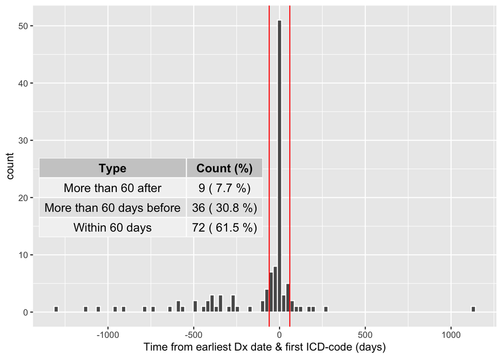

```r
uf_dates_comp <- true_df_clean %>%
  filter(mrn %in% uf_ids) %>%
  left_join(pred_df, by='mrn') %>%
  filter(uf_gold_dx == 'Incident' & uf_algorithm == 'Incident') %>%
  mutate(true_v_pred_date_gap = uf_earliest_dx_date-uf_first_dx_date,
         date_group = case_when(true_v_pred_date_gap < -60 ~'More than 60 days before',
                                true_v_pred_date_gap >= -60  & true_v_pred_date_gap <= 60 ~'Within 60 days',
                                true_v_pred_date_gap > 60 ~'More than 60 after'))

#summarize frequencies of date group in table
my_table <- as.data.frame(table(uf_dates_comp$date_group))
my_table$Freq <- paste(my_table$Freq, '(',round(my_table$Freq/sum(my_table$Freq)*100, 1),'%)')
names(my_table) <- c('Type', 'Count (%)')

ggplot(aes(x=as.numeric(true_v_pred_date_gap)), data=uf_dates_comp) +
  geom_histogram(bins = 100, color='white') +
  geom_vline(xintercept = 60, color='red') +
  geom_vline(xintercept = -60, color='red') +
  xlab('Time from earliest Dx date & first ICD-code (days)') +
  annotation_custom(tableGrob(my_table, rows=NULL), xmin=-1000, xmax=-500, ymin=20, ymax=20)
```

```r
summary(as.integer(uf_dates_comp$true_v_pred_date_gap/30))
```

```
##    Min. 1st Qu.  Median    Mean 3rd Qu.    Max.
## -43.000  -3.000   0.000  -3.906   0.000  37.000
```

```r
print(paste('The total misattributed person-time due to incorrect earliest UF dx date from ICD-10 in validation study is', round(sum(as.integer(uf_dates_comp$true_v_pred_date_gap/30)),2), 'person-months.'))
```

```
## [1] "The total misattributed person-time due to incorrect earliest UF dx date from ICD-10 in validation study is -457 person-months."
```

### Endometriosis

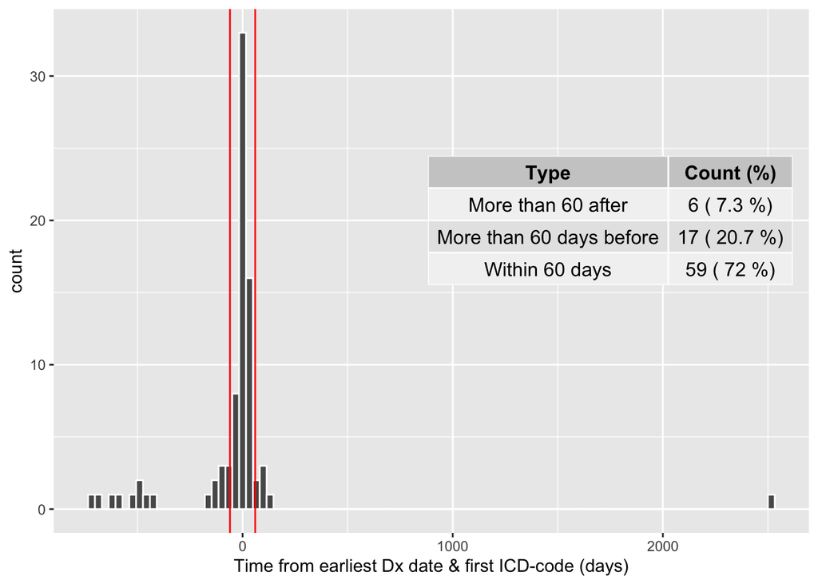

```r
library(gridExtra)

endo_dates_comp <- true_df_clean %>%
  filter(mrn %in% endo_ids) %>%
  left_join(pred_df, by='mrn') %>%
  filter(endo_gold_dx == 'Incident' & endo_algorithm == 'Incident') %>%
  mutate(true_v_pred_date_gap = endo_earliest_dx_date-endo_first_dx_date,
         date_group = case_when(true_v_pred_date_gap < -60 ~'More than 60 days before',
                                true_v_pred_date_gap >= -60  & true_v_pred_date_gap <= 60 ~'Within 60 days',
                                true_v_pred_date_gap > 60 ~'More than 60 after'))

#summarize frequencies of date group in table
my_table <- as.data.frame(table(endo_dates_comp$date_group))
my_table$Freq <- paste(my_table$Freq, '(',round(my_table$Freq/sum(my_table$Freq)*100, 1),'%)')
names(my_table) <- c('Type', 'Count (%)')

ggplot(aes(x=as.numeric(true_v_pred_date_gap)), data=endo_dates_comp) +
  geom_histogram(bins = 100, color='white') +
  geom_vline(xintercept = 60, color='red') +
  geom_vline(xintercept = -60, color='red') +
  xlab('Time from earliest Dx date & first ICD-code (days)') +
  annotation_custom(tableGrob(my_table, rows=NULL), xmin=1500, xmax=2000, ymin=20, ymax=20)
```

```r
summary(as.integer(endo_dates_comp$true_v_pred_date_gap/30))
```

```
##    Min. 1st Qu.  Median    Mean 3rd Qu.    Max.    NA's
## -24.000  -1.000   0.000  -1.061   0.000  83.000       1
```

```r
print(paste('The total misattributed person-time due to incorrect earliest dx Endo date from ICD-10 in validation study is', round(sum(as.integer(endo_dates_comp$true_v_pred_date_gap/30), na.rm=T),2), 'person-months.'))
```

```
## [1] "The total misattributed person-time due to incorrect earliest dx Endo date from ICD-10 in validation study is -87 person-months."
```

## Sensitivity validations

### Both cases

What percent are truly both? What percent are one but not the other? What percent are neither?

```r
both_df <- true_df_clean %>%
  filter(mrn %in% chart_info$mrn[which(chart_info$condition == 'Both')])
```

```r
both_df_clean <- both_df %>%
  mutate(both_gold_dx = case_when(uf_gold_dx == 'Incident' & endo_gold_dx == 'Incident'~'Both Incident',
                                  uf_gold_dx == 'No Dx' & endo_gold_dx == 'Incident'~'Endo only',
                                  uf_gold_dx == 'Incident' & endo_gold_dx == 'No Dx'~'UF only',
                                  uf_gold_dx == 'No Dx' & endo_gold_dx == 'No Dx'~'Neither',
                                  TRUE~'Other')) %>%
  left_join(pred_df %>% select(mrn, index_enc_date, final_outcome_status), by='mrn') %>%
  filter(final_outcome_status == 'Both Incident') %>%
  rename(both_pred_dx = final_outcome_status) %>%
  mutate(both_gold_dx = as.factor(both_gold_dx),
         both_pred_dx = as.factor(both_pred_dx))
```

```r
CreateTableOne(vars='both_gold_dx', data=both_df_clean)
```

```
##
##                    Overall
##   n                56
##   both_gold_dx (%)
##      Both Incident 22 (39.3)
##      Other         17 (30.4)
##      UF only       17 (30.4)
```

### False negatives

What percent are controls? What percent are prevalent cases? What percent are true cases?

```r
false_negative_df <- true_df_clean %>%
  left_join(chart_info, by='mrn') %>%
  filter(type == 'putative false positive')

CreateTableOne(vars=c('uf_gold_dx', 'endo_gold_dx'), data=false_negative_df)
```

```
##
##                            Overall
##   n                        75
##   uf_gold_dx (%)
##      Incident               9 ( 12.0)
##      No Dx                 60 ( 80.0)
##      Prevalent              6 (  8.0)
##   endo_gold_dx = No Dx (%) 75 (100.0)
```